# M6L2_Assignment

Xueyi Fan

June 30, 2016

# Assignemnt

1. Go to the UC Irvine Machine Learning Repository and find a dataset for supervised classification. Every student MUST use a different dataset so you MUST get approved for which you can going to use. This can be the same dataset you used for the unsupervised clustering as long as the data has some labeled data.
2. Generate a Decision Tree with your data. You can use any method/package you wish. Answer the following questions:
- Does the size of the data set make a difference?
- Do the rules make sense? If so why did the algorithm generate good rules? If not, why not?
- Does scaling, normalization or leaving the data unscaled make a difference?

```r
library("ggplot2")
library("C50")
library("gmodels")
library("rpart")
library("RColorBrewer")
library("tree")
library("party")
```

# Answer:

## 1. Loading the dataset

Here, I choose the [Breast Cancer Wisconsin (Diagnostic) data set](https://archive.ics.uci.edu/ml/machine-learning-databases/breast-cancer-wisconsin/)

```r
data_url <- 'https://archive.ics.uci.edu/ml/machine-learning-databases/breast-cancer-wisconsin/wdbc.data'

data <- read.table(url(data_url), sep = ',')

names(data) <- c('ID number', 'Diagnosis','radius_mean','texure_mean','perimeter_mean','area_mean','smoothness_mean','compactness_mean','concavity_mean','concave_points_mean','symmetry_mean','fractal_dimension_mean', 'radius_SE','texure_SE','perimeter_SE','area_SE','smoothness_SE','compactness_SE','concavity_SE','concave_points_SE','symmetry_SE','fractal_dimension_SE','radius_worst','texure_worst','perimeter_worst','area_worst','smoothness_worst','compactness_worst','concavity_worst','concave_points_worst','symmetry_worst','fractal_dimension_worst')

head(data)
```

```
##   ID number Diagnosis radius_mean texure_mean perimeter_mean area_mean
## 1    842302         M       17.99       10.38         122.80    1001.0
## 2    842517         M       20.57       17.77         132.90    1326.0
## 3  84300903         M       19.69       21.25         130.00    1203.0
## 4  84348301         M       11.42       20.38          77.58     386.1
## 5  84358402         M       20.29       14.34         135.10    1297.0
## 6    843786         M       12.45       15.70          82.57     477.1
##   smoothness_mean compactness_mean concavity_mean concave_points_mean
## 1         0.11840          0.27760         0.3001             0.14710
## 2         0.08474          0.07864         0.0869             0.07017
## 3         0.10960          0.15990         0.1974             0.12790
## 4         0.14250          0.28390         0.2414             0.10520
## 5         0.10030          0.13280         0.1980             0.10430
## 6         0.12780          0.17000         0.1578             0.08089
##   symmetry_mean fractal_dimension_mean radius_SE texure_SE perimeter_SE
```

[output cut: 41 more lines]

```r
str(data)
```

```
## 'data.frame':    569 obs. of  32 variables:
##  $ ID number              : int  842302 842517 84300903 84348301 84358402 843786 844359 84458202 844981 84501001 ...
##  $ Diagnosis              : Factor w/ 2 levels "B","M": 2 2 2 2 2 2 2 2 2 2 ...
##  $ radius_mean            : num  18 20.6 19.7 11.4 20.3 ...
##  $ texure_mean            : num  10.4 17.8 21.2 20.4 14.3 ...
##  $ perimeter_mean         : num  122.8 132.9 130 77.6 135.1 ...
##  $ area_mean              : num  1001 1326 1203 386 1297 ...
##  $ smoothness_mean        : num  0.1184 0.0847 0.1096 0.1425 0.1003 ...
##  $ compactness_mean       : num  0.2776 0.0786 0.1599 0.2839 0.1328 ...
##  $ concavity_mean         : num  0.3001 0.0869 0.1974 0.2414 0.198 ...
##  $ concave_points_mean    : num  0.1471 0.0702 0.1279 0.1052 0.1043 ...
##  $ symmetry_mean          : num  0.242 0.181 0.207 0.26 0.181 ...
##  $ fractal_dimension_mean : num  0.0787 0.0567 0.06 0.0974 0.0588 ...
##  $ radius_SE              : num  1.095 0.543 0.746 0.496 0.757 ...
##  $ texure_SE              : num  0.905 0.734 0.787 1.156 0.781 ...
```

[output cut: 18 more lines]

```r
summary(data)
```

```
##    ID number         Diagnosis  radius_mean      texure_mean
##  Min.   :     8670   B:357     Min.   : 6.981   Min.   : 9.71
##  1st Qu.:   869218   M:212     1st Qu.:11.700   1st Qu.:16.17
##  Median :   906024             Median :13.370   Median :18.84
##  Mean   : 30371831             Mean   :14.127   Mean   :19.29
##  3rd Qu.:  8813129             3rd Qu.:15.780   3rd Qu.:21.80
##  Max.   :911320502             Max.   :28.110   Max.   :39.28
##  perimeter_mean     area_mean      smoothness_mean   compactness_mean
##  Min.   : 43.79   Min.   : 143.5   Min.   :0.05263   Min.   :0.01938
##  1st Qu.: 75.17   1st Qu.: 420.3   1st Qu.:0.08637   1st Qu.:0.06492
##  Median : 86.24   Median : 551.1   Median :0.09587   Median :0.09263
##  Mean   : 91.97   Mean   : 654.9   Mean   :0.09636   Mean   :0.10434
##  3rd Qu.:104.10   3rd Qu.: 782.7   3rd Qu.:0.10530   3rd Qu.:0.13040
##  Max.   :188.50   Max.   :2501.0   Max.   :0.16340   Max.   :0.34540
##  concavity_mean    concave_points_mean symmetry_mean
##  Min.   :0.00000   Min.   :0.00000     Min.   :0.1060
##  1st Qu.:0.02956   1st Qu.:0.02031     1st Qu.:0.1619
##  Median :0.06154   Median :0.03350     Median :0.1792
##  Mean   :0.08880   Mean   :0.04892     Mean   :0.1812
##  3rd Qu.:0.13070   3rd Qu.:0.07400     3rd Qu.:0.1957
##  Max.   :0.42680   Max.   :0.20120     Max.   :0.3040
##  fractal_dimension_mean   radius_SE        texure_SE       perimeter_SE
##  Min.   :0.04996        Min.   :0.1115   Min.   :0.3602   Min.   : 0.757
##  1st Qu.:0.05770        1st Qu.:0.2324   1st Qu.:0.8339   1st Qu.: 1.606
##  Median :0.06154        Median :0.3242   Median :1.1080   Median : 2.287
##  Mean   :0.06280        Mean   :0.4052   Mean   :1.2169   Mean   : 2.866
##  3rd Qu.:0.06612        3rd Qu.:0.4789   3rd Qu.:1.4740   3rd Qu.: 3.357
##  Max.   :0.09744        Max.   :2.8730   Max.   :4.8850   Max.   :21.980
##     area_SE        smoothness_SE      compactness_SE      concavity_SE
##  Min.   :  6.802   Min.   :0.001713   Min.   :0.002252   Min.   :0.00000
##  1st Qu.: 17.850   1st Qu.:0.005169   1st Qu.:0.013080   1st Qu.:0.01509
##  Median : 24.530   Median :0.006380   Median :0.020450   Median :0.02589
##  Mean   : 40.337   Mean   :0.007041   Mean   :0.025478   Mean   :0.03189
##  3rd Qu.: 45.190   3rd Qu.:0.008146   3rd Qu.:0.032450   3rd Qu.:0.04205
##  Max.   :542.200   Max.   :0.031130   Max.   :0.135400   Max.   :0.39600
##  concave_points_SE   symmetry_SE       fractal_dimension_SE
##  Min.   :0.000000   Min.   :0.007882   Min.   :0.0008948
##  1st Qu.:0.007638   1st Qu.:0.015160   1st Qu.:0.0022480
##  Median :0.010930   Median :0.018730   Median :0.0031870
##  Mean   :0.011796   Mean   :0.020542   Mean   :0.0037949
```

[output cut: 8 more lines]

```
##  Max.   :36.04   Max.   :49.54   Max.   :251.20   Max.   :4254.0
##  smoothness_worst  compactness_worst concavity_worst  concave_points_worst
##  Min.   :0.07117   Min.   :0.02729   Min.   :0.0000   Min.   :0.00000
##  1st Qu.:0.11660   1st Qu.:0.14720   1st Qu.:0.1145   1st Qu.:0.06493
##  Median :0.13130   Median :0.21190   Median :0.2267   Median :0.09993
##  Mean   :0.13237   Mean   :0.25427   Mean   :0.2722   Mean   :0.11461
##  3rd Qu.:0.14600   3rd Qu.:0.33910   3rd Qu.:0.3829   3rd Qu.:0.16140
##  Max.   :0.22260   Max.   :1.05800   Max.   :1.2520   Max.   :0.29100
##  symmetry_worst   fractal_dimension_worst
##  Min.   :0.1565   Min.   :0.05504
##  1st Qu.:0.2504   1st Qu.:0.07146
##  Median :0.2822   Median :0.08004
##  Mean   :0.2901   Mean   :0.08395
##  3rd Qu.:0.3179   3rd Qu.:0.09208
##  Max.   :0.6638   Max.   :0.20750
```

```r
#shuffle the data
set.seed(123)
cancer_data <- data[order(runif(nrow(data))),]
cancer_data[,2]
```

```
##   [1] B M B B B B B B B M B B B B B B M M B M B B B B B B B M B B B B B M B
##  [36] B M B B B B M B B B B B B B B B B M M B B B B B B B B M B M B B B B B
##  [71] M B B M B B B B M M M B M B B B B M B B B M B B B B B B M B B M B B M
## [106] M M B B B M B B M B B B B B M M B M M B B B B M B B B M B M B B B B M
## [141] B B B M B B M B B M B B M B B M B B B M B B B M M M M B B B B B B M B
## [176] B B B M B M B B M M M B M B B B M M B B M M M B B B M M M B B M B B M
## [211] B B B M B M M B B B B B B B M B B B B B B B M B B B M B B B M M M M B
## [246] M M M M M M B M B M B B B M M B B B B B B M B B M M M M M B B B M M B
## [281] B M B M B B B B M B M B B B B M B B B B B B M M M M B M B B M B M B M
## [316] B B B B B B M B B B B M B M B B B M M M B M B M B B M B M M M B M M B
## [351] M M M B M B M B B B B B B B B M M B B B B M M M M M B M M B B B B B B
## [386] B B M M M M M M B B M M B B M M B B B B M B M M B M M B M B B B M B B
## [421] B B B B M B B M B B B B M B M B M M M B B M M M B M B M M M M B M M M
## [456] B M B B B B B M B B B M B B M B M B M B B B B M B B M B B M B B B B B
## [491] B M B M M M M B B M B M M B B B B M B M M M B B M B M B B B M B M M M
## [526] M B B B M B M B B M B M M B B M B M M B B B M B M B B M B M M B B B M
## [561] B B M B B B M M B
## Levels: B M
```

# 2. Generate a Decision Tree with my data

First of all, I will normalize my data

```r
normalize <- function(x){
  return((x-min(x))/(max(x)-min(x)))
}

cancer.normalized <- as.data.frame(lapply(cancer_data[,c(3:32)], normalize))
head(cancer.normalized)
```

```
##   radius_mean texure_mean perimeter_mean  area_mean smoothness_mean
## 1  0.32746462   0.2336828     0.31221063 0.19338282       0.1412837
## 2  0.32273179   0.2056138     0.32229977 0.18689290       0.4339623
## 3  0.20393772   0.1126141     0.19653099 0.10371156       0.4126569
## 4  0.09555587   0.1586067     0.08686338 0.04360551       0.1572628
## 5  0.25931185   0.3442678     0.25319605 0.13904560       0.2878036
## 6  0.21056368   0.2570172     0.20641283 0.10795334       0.5106978
##   compactness_mean concavity_mean concave_points_mean symmetry_mean
## 1       0.10370529    0.052108716          0.06655070     0.3803030
## 2       0.33316974    0.182497657          0.25193837     0.3040404
## 3       0.17391571    0.076499531          0.13692843     0.3580808
## 4       0.03613275    0.008624649          0.01725646     0.3676768
## 5       0.25157966    0.160028116          0.15402584     0.3641414
## 6       0.23151954    0.047586692          0.09249503     0.2954545
##   fractal_dimension_mean  radius_SE  texure_SE perimeter_SE     area_SE
```

[output cut: 34 more lines]

```r
summary(cancer.normalized)
```

```
##   radius_mean      texure_mean     perimeter_mean     area_mean
##  Min.   :0.0000   Min.   :0.0000   Min.   :0.0000   Min.   :0.0000
##  1st Qu.:0.2233   1st Qu.:0.2185   1st Qu.:0.2168   1st Qu.:0.1174
##  Median :0.3024   Median :0.3088   Median :0.2933   Median :0.1729
##  Mean   :0.3382   Mean   :0.3240   Mean   :0.3329   Mean   :0.2169
##  3rd Qu.:0.4164   3rd Qu.:0.4089   3rd Qu.:0.4168   3rd Qu.:0.2711
##  Max.   :1.0000   Max.   :1.0000   Max.   :1.0000   Max.   :1.0000
##  smoothness_mean  compactness_mean concavity_mean    concave_points_mean
##  Min.   :0.0000   Min.   :0.0000   Min.   :0.00000   Min.   :0.0000
##  1st Qu.:0.3046   1st Qu.:0.1397   1st Qu.:0.06926   1st Qu.:0.1009
##  Median :0.3904   Median :0.2247   Median :0.14419   Median :0.1665
##  Mean   :0.3948   Mean   :0.2606   Mean   :0.20806   Mean   :0.2431
##  3rd Qu.:0.4755   3rd Qu.:0.3405   3rd Qu.:0.30623   3rd Qu.:0.3678
##  Max.   :1.0000   Max.   :1.0000   Max.   :1.00000   Max.   :1.0000
##  symmetry_mean    fractal_dimension_mean   radius_SE
##  Min.   :0.0000   Min.   :0.0000         Min.   :0.00000
##  1st Qu.:0.2823   1st Qu.:0.1630         1st Qu.:0.04378
##  Median :0.3697   Median :0.2439         Median :0.07702
##  Mean   :0.3796   Mean   :0.2704         Mean   :0.10635
##  3rd Qu.:0.4530   3rd Qu.:0.3404         3rd Qu.:0.13304
##  Max.   :1.0000   Max.   :1.0000         Max.   :1.00000
##    texure_SE       perimeter_SE        area_SE        smoothness_SE
##  Min.   :0.0000   Min.   :0.00000   Min.   :0.00000   Min.   :0.0000
##  1st Qu.:0.1047   1st Qu.:0.04000   1st Qu.:0.02064   1st Qu.:0.1175
##  Median :0.1653   Median :0.07209   Median :0.03311   Median :0.1586
##  Mean   :0.1893   Mean   :0.09938   Mean   :0.06264   Mean   :0.1811
##  3rd Qu.:0.2462   3rd Qu.:0.12251   3rd Qu.:0.07170   3rd Qu.:0.2187
##  Max.   :1.0000   Max.   :1.00000   Max.   :1.00000   Max.   :1.0000
##  compactness_SE     concavity_SE     concave_points_SE  symmetry_SE
##  Min.   :0.00000   Min.   :0.00000   Min.   :0.0000    Min.   :0.0000
##  1st Qu.:0.08132   1st Qu.:0.03811   1st Qu.:0.1447    1st Qu.:0.1024
##  Median :0.13667   Median :0.06538   Median :0.2070    Median :0.1526
##  Mean   :0.17444   Mean   :0.08054   Mean   :0.2235    Mean   :0.1781
##  3rd Qu.:0.22680   3rd Qu.:0.10619   3rd Qu.:0.2787    3rd Qu.:0.2195
##  Max.   :1.00000   Max.   :1.00000   Max.   :1.0000    Max.   :1.0000
##  fractal_dimension_SE  radius_worst     texure_worst    perimeter_worst
##  Min.   :0.00000      Min.   :0.0000   Min.   :0.0000   Min.   :0.0000
##  1st Qu.:0.04675      1st Qu.:0.1807   1st Qu.:0.2415   1st Qu.:0.1678
##  Median :0.07919      Median :0.2504   Median :0.3569   Median :0.2353
##  Mean   :0.10019      Mean   :0.2967   Mean   :0.3640   Mean   :0.2831
##  3rd Qu.:0.12656      3rd Qu.:0.3863   3rd Qu.:0.4717   3rd Qu.:0.3735
##  Max.   :1.00000      Max.   :1.0000   Max.   :1.0000   Max.   :1.0000
##    area_worst      smoothness_worst compactness_worst concavity_worst
##  Min.   :0.00000   Min.   :0.0000   Min.   :0.0000    Min.   :0.00000
##  1st Qu.:0.08113   1st Qu.:0.3000   1st Qu.:0.1163    1st Qu.:0.09145
##  Median :0.12321   Median :0.3971   Median :0.1791    Median :0.18107
##  Mean   :0.17091   Mean   :0.4041   Mean   :0.2202    Mean   :0.21740
##  3rd Qu.:0.22090   3rd Qu.:0.4942   3rd Qu.:0.3025    3rd Qu.:0.30583
##  Max.   :1.00000   Max.   :1.0000   Max.   :1.0000    Max.   :1.00000
##  concave_points_worst symmetry_worst   fractal_dimension_worst
##  Min.   :0.0000       Min.   :0.0000   Min.   :0.0000
##  1st Qu.:0.2231       1st Qu.:0.1851   1st Qu.:0.1077
##  Median :0.3434       Median :0.2478   Median :0.1640
##  Mean   :0.3938       Mean   :0.2633   Mean   :0.1896
##  3rd Qu.:0.5546       3rd Qu.:0.3182   3rd Qu.:0.2429
##  Max.   :1.0000       Max.   :1.0000   Max.   :1.0000
```

```r
#split the data frames
cancer.normalized.train <- cancer.normalized[1:500,]
cancer.normalized.test <- cancer.normalized[501:569,]
cancer.normalized.train.target<- cancer_data[1:500,2]
cancer.normalized.test.target <- cancer_data[501:569,2]

#check the proportion of class variable

prop.table(table(cancer_data[,2]))
```

```
##
##         B         M
## 0.6274165 0.3725835
```

Then, I will use the method C5.0, rpart, tree, ctree to generate the decision trees.

```r
#use C5.0
cancer.c5.0 <- C5.0(cancer.normalized.train, cancer.normalized.train.target)
cancer.c5.0
```

```
##
## Call:
## C5.0.default(x = cancer.normalized.train, y
##  = cancer.normalized.train.target)
##
## Classification Tree
## Number of samples: 500
## Number of predictors: 30
##
## Tree size: 9
##
## Non-standard options: attempt to group attributes
```

```r
summary(cancer.c5.0)
```

```
##
## Call:
## C5.0.default(x = cancer.normalized.train, y
##  = cancer.normalized.train.target)
##
##
## C5.0 [Release 2.07 GPL Edition]      Thu Jun 30 19:42:49 2016
## -------------------------------
##
## Class specified by attribute `outcome'
##
## Read 500 cases (31 attributes) from undefined.data
##
## Decision tree:
##
## radius_worst > 0.3144788:
## :...texure_mean > 0.1782212: M (156/2)
## :   texure_mean <= 0.1782212:
## :   :...concavity_mean <= 0.3202905: B (6)
## :       concavity_mean > 0.3202905: M (3)
## radius_worst <= 0.3144788:
## :...concave_points_worst <= 0.466323: B (298/4)
##     concave_points_worst > 0.466323:
##     :...texure_worst > 0.4123134: M (14)
##         texure_worst <= 0.4123134:
##         :...concave_points_worst > 0.6147766: M (2)
##             concave_points_worst <= 0.6147766:
##             :...area_worst <= 0.1311689: B (10)
##                 area_worst > 0.1311689:
##                 :...radius_mean <= 0.3411898: M (4)
##                     radius_mean > 0.3411898: B (7/1)
##
##
## Evaluation on training data (500 cases):
##
##      Decision Tree
##    ----------------
##    Size      Errors
##
##       9    7( 1.4%)   <<
##
##
##     (a)   (b)    <-classified as
##    ----  ----
##     316     2    (a): class B
##       5   177    (b): class M
##
##
##  Attribute usage:
##
##  100.00% radius_worst
##   67.00% concave_points_worst
##   33.00% texure_mean
##    7.40% texure_worst
##    4.20% area_worst
##    2.20% radius_mean
##    1.80% concavity_mean
##
##
## Time: 0.0 secs
```

```r
#use rpart
cancer.rpart <- rpart(cancer_data[1:500,2]~., data=cancer.normalized.train, method="class")
printcp(cancer.rpart)
```

```
##
## Classification tree:
## rpart(formula = cancer_data[1:500, 2] ~ ., data = cancer.normalized.train,
##     method = "class")
##
## Variables actually used in tree construction:
## [1] concave_points_worst radius_worst         texure_mean
##
## Root node error: 182/500 = 0.364
##
## n= 500
##
##         CP nsplit rel error  xerror     xstd
## 1 0.818681      0  1.000000 1.00000 0.059114
## 2 0.049451      1  0.181319 0.18132 0.030504
## 3 0.021978      2  0.131868 0.16484 0.029178
## 4 0.016484      3  0.109890 0.15385 0.028248
## 5 0.010000      4  0.093407 0.17582 0.030071
```

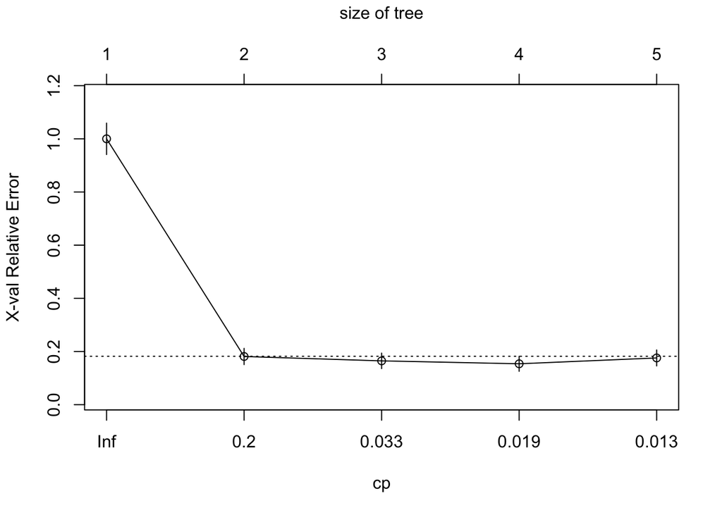

```r
plotcp(cancer.rpart)
```

```r
summary(cancer.rpart)
```

```
## Call:
## rpart(formula = cancer_data[1:500, 2] ~ ., data = cancer.normalized.train,
##     method = "class")
##   n= 500
##
##           CP nsplit  rel error    xerror       xstd
## 1 0.81868132      0 1.00000000 1.0000000 0.05911434
## 2 0.04945055      1 0.18131868 0.1813187 0.03050416
## 3 0.02197802      2 0.13186813 0.1648352 0.02917784
## 4 0.01648352      3 0.10989011 0.1538462 0.02824839
## 5 0.01000000      4 0.09340659 0.1758242 0.03007056
##
## Variable importance
##         radius_worst           area_worst      perimeter_worst
##                   16                   16                   16
##            area_mean          radius_mean       perimeter_mean
##                   15                   14                   14
## concave_points_worst          texure_mean      concavity_worst
##                    2                    1                    1
##    compactness_worst         texure_worst       concavity_mean
##                    1                    1                    1
##  concave_points_mean       symmetry_worst
##                    1                    1
##
## Node number 1: 500 observations,    complexity param=0.8186813
##   predicted class=B  expected loss=0.364  P(node) =1
##     class counts:   318   182
##    probabilities: 0.636 0.364
##   left son=2 (335 obs) right son=3 (165 obs)
##   Primary splits:
##       radius_worst         < 0.3157239  to the left,  improve=170.0111, (0 missing)
##       area_worst           < 0.1718811  to the left,  improve=165.0636, (0 missing)
##       concave_points_worst < 0.4891753  to the left,  improve=163.1507, (0 missing)
##       perimeter_worst      < 0.3042482  to the left,  improve=162.9821, (0 missing)
##       concave_points_mean  < 0.2557406  to the left,  improve=157.7055, (0 missing)
##   Surrogate splits:
##       area_worst      < 0.1678628  to the left,  agree=0.994, adj=0.982, (0 split)
##       perimeter_worst < 0.3052443  to the left,  agree=0.982, adj=0.945, (0 split)
##       area_mean       < 0.2362036  to the left,  agree=0.964, adj=0.891, (0 split)
##       radius_mean     < 0.3816555  to the left,  agree=0.962, adj=0.885, (0 split)
```

[output cut: 64 more lines]

```
##
## Node number 7: 156 observations
##   predicted class=M  expected loss=0.01282051  P(node) =0.312
##     class counts:     2   154
##    probabilities: 0.013 0.987
##
## Node number 10: 14 observations
##   predicted class=B  expected loss=0.3571429  P(node) =0.028
##     class counts:     9     5
##    probabilities: 0.643 0.357
##
## Node number 11: 13 observations
##   predicted class=M  expected loss=0  P(node) =0.026
##     class counts:     0    13
##    probabilities: 0.000 1.000
```

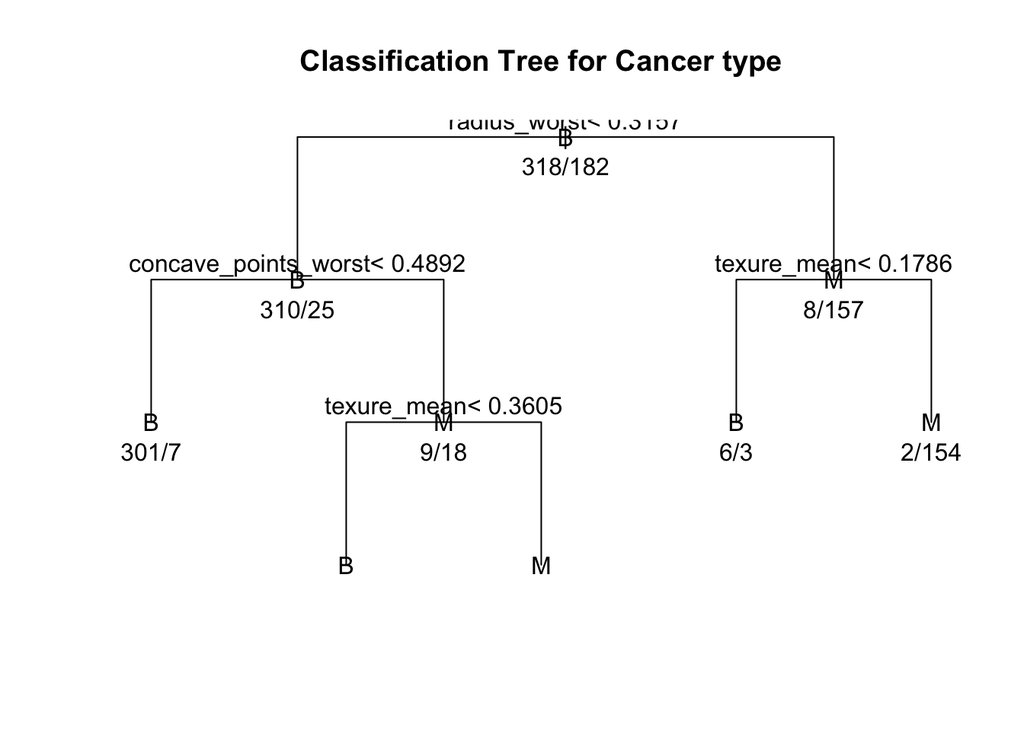

```r
  #plot tree
plot(cancer.rpart, uniform = T, main = "Classification Tree for Cancer type")
text(cancer.rpart, use.n = T, all= T)
```

```r
#use tree
cancer.tree <- tree(cancer_data[1:500,2]~., data=cancer.normalized.train)
summary(cancer.tree)
```

```
##
## Classification tree:
## tree(formula = cancer_data[1:500, 2] ~ ., data = cancer.normalized.train)
## Variables actually used in tree construction:
## [1] "radius_worst"         "concave_points_worst" "radius_SE"
## [4] "texure_worst"         "texure_mean"          "area_SE"
## [7] "perimeter_SE"         "concavity_mean"
## Number of terminal nodes:  10
## Residual mean deviance:  0.05824 = 28.54 / 490
## Misclassification error rate: 0.01 = 5 / 500
```

```r
plot(cancer.tree)
text(cancer.tree)
```

[output not shown]

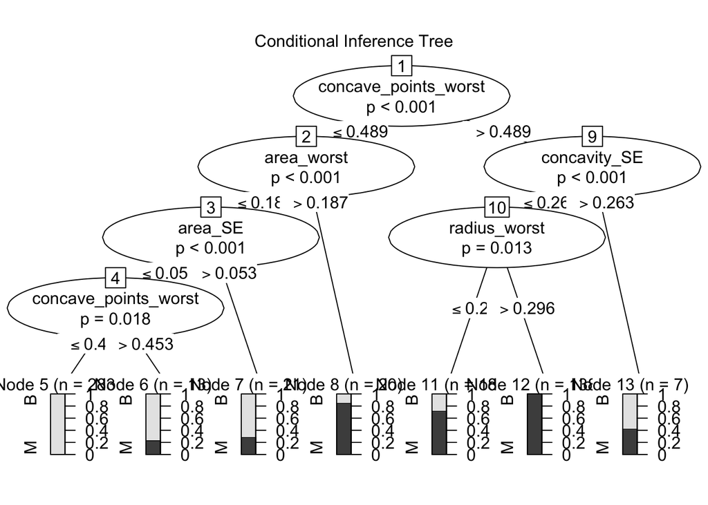

```r
#use ctree
cancer.ctree <- ctree(cancer_data[1:500,2]~., data=cancer.normalized.train)
plot(cancer.ctree, main = "Conditional Inference Tree")
```

# Answer the following questions:

I choose “tree” as my method. And the original size of my data is 569.

## Does the size of the data set make a difference?

```r
#use the orginal size of data
cancer.tree.whole <- tree(cancer_data[1:500,2]~., data=cancer.normalized.train)
summary(cancer.tree.whole)
```

```
##
## Classification tree:
## tree(formula = cancer_data[1:500, 2] ~ ., data = cancer.normalized.train)
## Variables actually used in tree construction:
## [1] "radius_worst"         "concave_points_worst" "radius_SE"
## [4] "texure_worst"         "texure_mean"          "area_SE"
## [7] "perimeter_SE"         "concavity_mean"
## Number of terminal nodes:  10
## Residual mean deviance:  0.05824 = 28.54 / 490
## Misclassification error rate: 0.01 = 5 / 500
```

```r
plot(cancer.tree.whole)
text(cancer.tree.whole)
```

[output not shown]

```r
#use half of the data
cancer.half.train <- cancer.normalized[1:250,]
cancer.half.test <- cancer.normalized[501:569,]
cancer.half.train.target<- cancer_data[1:250,2]
cancer.half.test.target <- cancer_data[501:569,2]

cancer.tree.half<- tree(cancer.half.train.target~., data= cancer.half.train)
summary(cancer.tree.half)
```

```
##
## Classification tree:
## tree(formula = cancer.half.train.target ~ ., data = cancer.half.train)
## Variables actually used in tree construction:
## [1] "radius_worst"         "concave_points_worst" "area_mean"
## [4] "radius_SE"            "texure_mean"          "smoothness_mean"
## [7] "concavity_mean"
## Number of terminal nodes:  8
## Residual mean deviance:  0.1309 = 31.68 / 242
## Misclassification error rate: 0.036 = 9 / 250
```

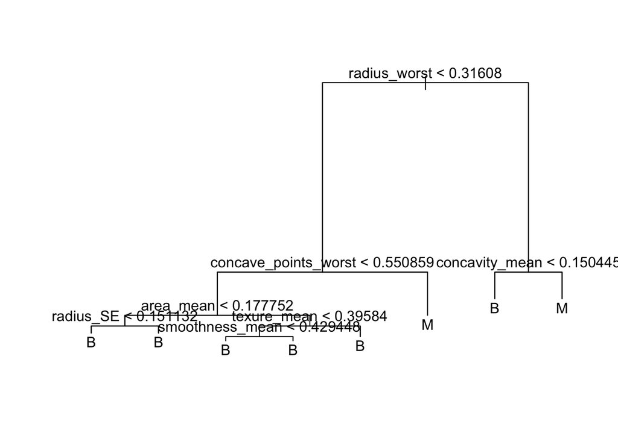

```r
plot(cancer.tree.half)
text(cancer.tree.half)
```

```r
#evaluate the performances of the models of the two datasets

#whole data set
cancer.whole.pred <- predict(cancer.tree.whole, cancer.normalized.test, type="class")
CrossTable(cancer.normalized.test.target, cancer.whole.pred, prop.chisq = F, prop.c = F, prop.r = F, dnn = c('actual type', 'predicted type'))
```

```
##
##
##    Cell Contents
## |-------------------------|
## |                       N |
## |         N / Table Total |
## |-------------------------|
##
##
## Total Observations in Table:  69
##
##
##              | predicted type
##  actual type |         B |         M | Row Total |
## -------------|-----------|-----------|-----------|
##            B |        38 |         1 |        39 |
##              |     0.551 |     0.014 |           |
## -------------|-----------|-----------|-----------|
##            M |         4 |        26 |        30 |
##              |     0.058 |     0.377 |           |
## -------------|-----------|-----------|-----------|
## Column Total |        42 |        27 |        69 |
## -------------|-----------|-----------|-----------|
##
##
```

```r
#half-size data set
cancer.half.pred <- predict(cancer.tree.half, cancer.half.test, type= "class")
CrossTable(cancer.half.test.target, cancer.half.pred, prop.chisq = F, prop.c = F, prop.r = F, dnn = c('actual type', 'predicted type'))
```

```
##
##
##    Cell Contents
## |-------------------------|
## |                       N |
## |         N / Table Total |
## |-------------------------|
##
##
## Total Observations in Table:  69
##
##
##              | predicted type
##  actual type |         B |         M | Row Total |
## -------------|-----------|-----------|-----------|
##            B |        36 |         3 |        39 |
##              |     0.522 |     0.043 |           |
## -------------|-----------|-----------|-----------|
##            M |         3 |        27 |        30 |
##              |     0.043 |     0.391 |           |
## -------------|-----------|-----------|-----------|
## Column Total |        39 |        30 |        69 |
## -------------|-----------|-----------|-----------|
##
##
```

I used different size of data to generate the models and used the same data to test the performances of these models. When I used whole data set, the misclassification is 5, while I used half size of data, the misclassification is 6. That means the size of data set makes a difference.

## Do the rules make sense? If so why did the algorithm generate good rules? If not, why not?

```r
#use the whole data set and "tree" as the method
plot(cancer.tree.whole)
text(cancer.tree.whole)
```

[output not shown]

According to my decision tree, there are 10 rules. For example, if the largest radius (radius_worst) is less than 0.3157, largest concave point is less than 0.467, the standard error of radius is less than 0.185, and the largest texure is less than 0.48, then the cancer is begign; If the largest radius is greater than 0.31, and the mean of concavity is greater than 0.169, the cancer is malignant.

The rules make sense. For example, if the tumor is small, it is highly possible that this tumor is benign and if the tumor is large, it is highly possible that this tumor is malignant. A decision tree is split the data set into subsets based on an attribute value test. and in general, doctor make a dignostic of the cancer is also depend on the attributes of the tumor or tissue for example the radius, the standard deviation of gray-scale values (texture). So the algorithm generate good rules.

## Does scaling, normalization or leaving the data unscaled make a difference?

Here, I use the whole data set and “tree” as the method

```r
#scaling data
cancer.scaled <- as.data.frame(lapply(cancer_data[,c(3:32)], scale))
head(cancer.scaled)
```

```
##   radius_mean texure_mean perimeter_mean  area_mean smoothness_mean
## 1 -0.06449733  -0.6206990    -0.12342219 -0.1576780      -1.9965888
## 2 -0.09287378  -0.8136758    -0.06333736 -0.2011545       0.3085665
## 3 -0.80512271  -1.4530566    -0.81233996 -0.7583927       0.1407637
## 4 -1.45494345  -1.1368537    -1.46545377 -1.1610477      -1.8707367
## 5 -0.47311823   0.1395830    -0.47487725 -0.5216872      -0.8425891
## 6 -0.76539568  -0.4602725    -0.75348976 -0.7299767       0.9129410
##   compactness_mean concavity_mean concave_points_mean symmetry_mean
## 1       -0.9685346     -0.8349156         -0.91563250   0.005038873
## 2        0.4479792     -0.1368457          0.04563722  -0.545768927
## 3       -0.5351166     -0.7043333         -0.55071080  -0.155461413
## 4       -1.3856687     -1.0677185         -1.17123232  -0.086154471
## 5       -0.0556870     -0.2571421         -0.46205751  -0.111688608
## 6       -0.1795207     -0.8591254         -0.78110628  -0.607780402
##   fractal_dimension_mean  radius_SE  texure_SE perimeter_SE    area_SE
```

[output cut: 34 more lines]

```r
summary(cancer.scaled)
```

```
##   radius_mean       texure_mean      perimeter_mean      area_mean
##  Min.   :-2.0279   Min.   :-2.2273   Min.   :-1.9828   Min.   :-1.4532
##  1st Qu.:-0.6888   1st Qu.:-0.7253   1st Qu.:-0.6913   1st Qu.:-0.6666
##  Median :-0.2149   Median :-0.1045   Median :-0.2358   Median :-0.2949
##  Mean   : 0.0000   Mean   : 0.0000   Mean   : 0.0000   Mean   : 0.0000
##  3rd Qu.: 0.4690   3rd Qu.: 0.5837   3rd Qu.: 0.4992   3rd Qu.: 0.3632
##  Max.   : 3.9678   Max.   : 4.6478   Max.   : 3.9726   Max.   : 5.2459
##  smoothness_mean    compactness_mean  concavity_mean
##  Min.   :-3.10935   Min.   :-1.6087   Min.   :-1.1139
##  1st Qu.:-0.71034   1st Qu.:-0.7464   1st Qu.:-0.7431
##  Median :-0.03486   Median :-0.2217   Median :-0.3419
##  Mean   : 0.00000   Mean   : 0.0000   Mean   : 0.0000
##  3rd Qu.: 0.63564   3rd Qu.: 0.4934   3rd Qu.: 0.5256
##  Max.   : 4.76672   Max.   : 4.5644   Max.   : 4.2399
##  concave_points_mean symmetry_mean      fractal_dimension_mean
##  Min.   :-1.2607     Min.   :-2.74171   Min.   :-1.8183
##  1st Qu.:-0.7373     1st Qu.:-0.70262   1st Qu.:-0.7220
##  Median :-0.3974     Median :-0.07156   Median :-0.1781
##  Mean   : 0.0000     Mean   : 0.00000   Mean   : 0.0000
##  3rd Qu.: 0.6464     3rd Qu.: 0.53031   3rd Qu.: 0.4706
##  Max.   : 3.9245     Max.   : 4.48081   Max.   : 4.9066
##    radius_SE         texure_SE        perimeter_SE        area_SE
##  Min.   :-1.0590   Min.   :-1.5529   Min.   :-1.0431   Min.   :-0.7372
##  1st Qu.:-0.6230   1st Qu.:-0.6942   1st Qu.:-0.6232   1st Qu.:-0.4943
##  Median :-0.2920   Median :-0.1973   Median :-0.2864   Median :-0.3475
##  Mean   : 0.0000   Mean   : 0.0000   Mean   : 0.0000   Mean   : 0.0000
##  3rd Qu.: 0.2659   3rd Qu.: 0.4661   3rd Qu.: 0.2428   3rd Qu.: 0.1067
##  Max.   : 8.8991   Max.   : 6.6494   Max.   : 9.4537   Max.   :11.0321
##  smoothness_SE     compactness_SE     concavity_SE     concave_points_SE
##  Min.   :-1.7745   Min.   :-1.2970   Min.   :-1.0566   Min.   :-1.9118
##  1st Qu.:-0.6235   1st Qu.:-0.6923   1st Qu.:-0.5567   1st Qu.:-0.6739
##  Median :-0.2201   Median :-0.2808   Median :-0.1989   Median :-0.1404
##  Mean   : 0.0000   Mean   : 0.0000   Mean   : 0.0000   Mean   : 0.0000
##  3rd Qu.: 0.3680   3rd Qu.: 0.3893   3rd Qu.: 0.3365   3rd Qu.: 0.4722
##  Max.   : 8.0229   Max.   : 6.1381   Max.   :12.0621   Max.   : 6.6438
##   symmetry_SE      fractal_dimension_SE  radius_worst
##  Min.   :-1.5315   Min.   :-1.0960      Min.   :-1.7254
##  1st Qu.:-0.6511   1st Qu.:-0.5846      1st Qu.:-0.6743
##  Median :-0.2192   Median :-0.2297      Median :-0.2688
##  Mean   : 0.0000   Mean   : 0.0000      Mean   : 0.0000
```

[output cut: 8 more lines]

```
##  Max.   : 3.88249   Max.   : 4.2836   Max.   : 5.9250   Max.   : 3.9519
##  compactness_worst concavity_worst   concave_points_worst
##  Min.   :-1.4426   Min.   :-1.3047   Min.   :-1.7435
##  1st Qu.:-0.6805   1st Qu.:-0.7558   1st Qu.:-0.7557
##  Median :-0.2693   Median :-0.2180   Median :-0.2233
##  Mean   : 0.0000   Mean   : 0.0000   Mean   : 0.0000
##  3rd Qu.: 0.5392   3rd Qu.: 0.5307   3rd Qu.: 0.7119
##  Max.   : 5.1084   Max.   : 4.6965   Max.   : 2.6835
##  symmetry_worst    fractal_dimension_worst
##  Min.   :-2.1591   Min.   :-1.6004
##  1st Qu.:-0.6413   1st Qu.:-0.6913
##  Median :-0.1273   Median :-0.2163
##  Mean   : 0.0000   Mean   : 0.0000
##  3rd Qu.: 0.4497   3rd Qu.: 0.4504
##  Max.   : 6.0407   Max.   : 6.8408
```

```r
#normalization data
normalize <- function(x) {
  return((x-min(x))/(max(x)-min(x)))
}
cancer.normalized <- as.data.frame(lapply(cancer_data[,c(3:32)],normalize))
head(cancer.normalized)
```

```
##   radius_mean texure_mean perimeter_mean  area_mean smoothness_mean
## 1  0.32746462   0.2336828     0.31221063 0.19338282       0.1412837
## 2  0.32273179   0.2056138     0.32229977 0.18689290       0.4339623
## 3  0.20393772   0.1126141     0.19653099 0.10371156       0.4126569
## 4  0.09555587   0.1586067     0.08686338 0.04360551       0.1572628
## 5  0.25931185   0.3442678     0.25319605 0.13904560       0.2878036
## 6  0.21056368   0.2570172     0.20641283 0.10795334       0.5106978
##   compactness_mean concavity_mean concave_points_mean symmetry_mean
## 1       0.10370529    0.052108716          0.06655070     0.3803030
## 2       0.33316974    0.182497657          0.25193837     0.3040404
## 3       0.17391571    0.076499531          0.13692843     0.3580808
## 4       0.03613275    0.008624649          0.01725646     0.3676768
## 5       0.25157966    0.160028116          0.15402584     0.3641414
## 6       0.23151954    0.047586692          0.09249503     0.2954545
##   fractal_dimension_mean  radius_SE  texure_SE perimeter_SE     area_SE
```

[output cut: 34 more lines]

```r
summary(cancer.normalized)
```

```
##   radius_mean      texure_mean     perimeter_mean     area_mean
##  Min.   :0.0000   Min.   :0.0000   Min.   :0.0000   Min.   :0.0000
##  1st Qu.:0.2233   1st Qu.:0.2185   1st Qu.:0.2168   1st Qu.:0.1174
##  Median :0.3024   Median :0.3088   Median :0.2933   Median :0.1729
##  Mean   :0.3382   Mean   :0.3240   Mean   :0.3329   Mean   :0.2169
##  3rd Qu.:0.4164   3rd Qu.:0.4089   3rd Qu.:0.4168   3rd Qu.:0.2711
##  Max.   :1.0000   Max.   :1.0000   Max.   :1.0000   Max.   :1.0000
##  smoothness_mean  compactness_mean concavity_mean    concave_points_mean
##  Min.   :0.0000   Min.   :0.0000   Min.   :0.00000   Min.   :0.0000
##  1st Qu.:0.3046   1st Qu.:0.1397   1st Qu.:0.06926   1st Qu.:0.1009
##  Median :0.3904   Median :0.2247   Median :0.14419   Median :0.1665
##  Mean   :0.3948   Mean   :0.2606   Mean   :0.20806   Mean   :0.2431
##  3rd Qu.:0.4755   3rd Qu.:0.3405   3rd Qu.:0.30623   3rd Qu.:0.3678
##  Max.   :1.0000   Max.   :1.0000   Max.   :1.00000   Max.   :1.0000
##  symmetry_mean    fractal_dimension_mean   radius_SE
##  Min.   :0.0000   Min.   :0.0000         Min.   :0.00000
##  1st Qu.:0.2823   1st Qu.:0.1630         1st Qu.:0.04378
##  Median :0.3697   Median :0.2439         Median :0.07702
##  Mean   :0.3796   Mean   :0.2704         Mean   :0.10635
##  3rd Qu.:0.4530   3rd Qu.:0.3404         3rd Qu.:0.13304
##  Max.   :1.0000   Max.   :1.0000         Max.   :1.00000
##    texure_SE       perimeter_SE        area_SE        smoothness_SE
##  Min.   :0.0000   Min.   :0.00000   Min.   :0.00000   Min.   :0.0000
##  1st Qu.:0.1047   1st Qu.:0.04000   1st Qu.:0.02064   1st Qu.:0.1175
##  Median :0.1653   Median :0.07209   Median :0.03311   Median :0.1586
##  Mean   :0.1893   Mean   :0.09938   Mean   :0.06264   Mean   :0.1811
##  3rd Qu.:0.2462   3rd Qu.:0.12251   3rd Qu.:0.07170   3rd Qu.:0.2187
##  Max.   :1.0000   Max.   :1.00000   Max.   :1.00000   Max.   :1.0000
##  compactness_SE     concavity_SE     concave_points_SE  symmetry_SE
##  Min.   :0.00000   Min.   :0.00000   Min.   :0.0000    Min.   :0.0000
##  1st Qu.:0.08132   1st Qu.:0.03811   1st Qu.:0.1447    1st Qu.:0.1024
##  Median :0.13667   Median :0.06538   Median :0.2070    Median :0.1526
##  Mean   :0.17444   Mean   :0.08054   Mean   :0.2235    Mean   :0.1781
##  3rd Qu.:0.22680   3rd Qu.:0.10619   3rd Qu.:0.2787    3rd Qu.:0.2195
##  Max.   :1.00000   Max.   :1.00000   Max.   :1.0000    Max.   :1.0000
##  fractal_dimension_SE  radius_worst     texure_worst    perimeter_worst
##  Min.   :0.00000      Min.   :0.0000   Min.   :0.0000   Min.   :0.0000
##  1st Qu.:0.04675      1st Qu.:0.1807   1st Qu.:0.2415   1st Qu.:0.1678
##  Median :0.07919      Median :0.2504   Median :0.3569   Median :0.2353
##  Mean   :0.10019      Mean   :0.2967   Mean   :0.3640   Mean   :0.2831
##  3rd Qu.:0.12656      3rd Qu.:0.3863   3rd Qu.:0.4717   3rd Qu.:0.3735
##  Max.   :1.00000      Max.   :1.0000   Max.   :1.0000   Max.   :1.0000
##    area_worst      smoothness_worst compactness_worst concavity_worst
##  Min.   :0.00000   Min.   :0.0000   Min.   :0.0000    Min.   :0.00000
##  1st Qu.:0.08113   1st Qu.:0.3000   1st Qu.:0.1163    1st Qu.:0.09145
##  Median :0.12321   Median :0.3971   Median :0.1791    Median :0.18107
##  Mean   :0.17091   Mean   :0.4041   Mean   :0.2202    Mean   :0.21740
##  3rd Qu.:0.22090   3rd Qu.:0.4942   3rd Qu.:0.3025    3rd Qu.:0.30583
##  Max.   :1.00000   Max.   :1.0000   Max.   :1.0000    Max.   :1.00000
##  concave_points_worst symmetry_worst   fractal_dimension_worst
##  Min.   :0.0000       Min.   :0.0000   Min.   :0.0000
##  1st Qu.:0.2231       1st Qu.:0.1851   1st Qu.:0.1077
##  Median :0.3434       Median :0.2478   Median :0.1640
##  Mean   :0.3938       Mean   :0.2633   Mean   :0.1896
##  3rd Qu.:0.5546       3rd Qu.:0.3182   3rd Qu.:0.2429
##  Max.   :1.0000       Max.   :1.0000   Max.   :1.0000
```

```r
#unscaling data
cancer.unscaled <- as.data.frame(cancer_data[,c(3:32)])
head(cancer.unscaled)
```

```
##     radius_mean texure_mean perimeter_mean area_mean smoothness_mean
## 478       13.90       16.62          88.97     599.4         0.06828
## 74        13.80       15.79          90.43     584.1         0.10070
## 272       11.29       13.04          72.23     388.0         0.09834
## 308        9.00       14.40          56.36     246.3         0.07005
## 302       12.46       19.89          80.43     471.3         0.08451
## 143       11.43       17.31          73.66     398.0         0.10920
##     compactness_mean concavity_mean concave_points_mean symmetry_mean
## 478          0.05319       0.022240            0.013390        0.1813
## 74           0.12800       0.077890            0.050690        0.1662
## 272          0.07608       0.032650            0.027550        0.1769
## 308          0.03116       0.003681            0.003472        0.1788
## 302          0.10140       0.068300            0.030990        0.1781
## 143          0.09486       0.020310            0.018610        0.1645
##     fractal_dimension_mean radius_SE texure_SE perimeter_SE area_SE
```

[output cut: 41 more lines]

```r
summary(cancer.unscaled)
```

```
##   radius_mean      texure_mean    perimeter_mean     area_mean
##  Min.   : 6.981   Min.   : 9.71   Min.   : 43.79   Min.   : 143.5
##  1st Qu.:11.700   1st Qu.:16.17   1st Qu.: 75.17   1st Qu.: 420.3
##  Median :13.370   Median :18.84   Median : 86.24   Median : 551.1
##  Mean   :14.127   Mean   :19.29   Mean   : 91.97   Mean   : 654.9
##  3rd Qu.:15.780   3rd Qu.:21.80   3rd Qu.:104.10   3rd Qu.: 782.7
##  Max.   :28.110   Max.   :39.28   Max.   :188.50   Max.   :2501.0
##  smoothness_mean   compactness_mean  concavity_mean    concave_points_mean
##  Min.   :0.05263   Min.   :0.01938   Min.   :0.00000   Min.   :0.00000
##  1st Qu.:0.08637   1st Qu.:0.06492   1st Qu.:0.02956   1st Qu.:0.02031
##  Median :0.09587   Median :0.09263   Median :0.06154   Median :0.03350
##  Mean   :0.09636   Mean   :0.10434   Mean   :0.08880   Mean   :0.04892
##  3rd Qu.:0.10530   3rd Qu.:0.13040   3rd Qu.:0.13070   3rd Qu.:0.07400
##  Max.   :0.16340   Max.   :0.34540   Max.   :0.42680   Max.   :0.20120
##  symmetry_mean    fractal_dimension_mean   radius_SE        texure_SE
##  Min.   :0.1060   Min.   :0.04996        Min.   :0.1115   Min.   :0.3602
##  1st Qu.:0.1619   1st Qu.:0.05770        1st Qu.:0.2324   1st Qu.:0.8339
##  Median :0.1792   Median :0.06154        Median :0.3242   Median :1.1080
##  Mean   :0.1812   Mean   :0.06280        Mean   :0.4052   Mean   :1.2169
##  3rd Qu.:0.1957   3rd Qu.:0.06612        3rd Qu.:0.4789   3rd Qu.:1.4740
##  Max.   :0.3040   Max.   :0.09744        Max.   :2.8730   Max.   :4.8850
##   perimeter_SE       area_SE        smoothness_SE      compactness_SE
##  Min.   : 0.757   Min.   :  6.802   Min.   :0.001713   Min.   :0.002252
##  1st Qu.: 1.606   1st Qu.: 17.850   1st Qu.:0.005169   1st Qu.:0.013080
##  Median : 2.287   Median : 24.530   Median :0.006380   Median :0.020450
##  Mean   : 2.866   Mean   : 40.337   Mean   :0.007041   Mean   :0.025478
##  3rd Qu.: 3.357   3rd Qu.: 45.190   3rd Qu.:0.008146   3rd Qu.:0.032450
##  Max.   :21.980   Max.   :542.200   Max.   :0.031130   Max.   :0.135400
##   concavity_SE     concave_points_SE   symmetry_SE
##  Min.   :0.00000   Min.   :0.000000   Min.   :0.007882
##  1st Qu.:0.01509   1st Qu.:0.007638   1st Qu.:0.015160
##  Median :0.02589   Median :0.010930   Median :0.018730
##  Mean   :0.03189   Mean   :0.011796   Mean   :0.020542
##  3rd Qu.:0.04205   3rd Qu.:0.014710   3rd Qu.:0.023480
##  Max.   :0.39600   Max.   :0.052790   Max.   :0.078950
##  fractal_dimension_SE  radius_worst    texure_worst   perimeter_worst
##  Min.   :0.0008948    Min.   : 7.93   Min.   :12.02   Min.   : 50.41
##  1st Qu.:0.0022480    1st Qu.:13.01   1st Qu.:21.08   1st Qu.: 84.11
##  Median :0.0031870    Median :14.97   Median :25.41   Median : 97.66
##  Mean   :0.0037949    Mean   :16.27   Mean   :25.68   Mean   :107.26
##  3rd Qu.:0.0045580    3rd Qu.:18.79   3rd Qu.:29.72   3rd Qu.:125.40
##  Max.   :0.0298400    Max.   :36.04   Max.   :49.54   Max.   :251.20
##    area_worst     smoothness_worst  compactness_worst concavity_worst
##  Min.   : 185.2   Min.   :0.07117   Min.   :0.02729   Min.   :0.0000
##  1st Qu.: 515.3   1st Qu.:0.11660   1st Qu.:0.14720   1st Qu.:0.1145
##  Median : 686.5   Median :0.13130   Median :0.21190   Median :0.2267
##  Mean   : 880.6   Mean   :0.13237   Mean   :0.25427   Mean   :0.2722
##  3rd Qu.:1084.0   3rd Qu.:0.14600   3rd Qu.:0.33910   3rd Qu.:0.3829
##  Max.   :4254.0   Max.   :0.22260   Max.   :1.05800   Max.   :1.2520
##  concave_points_worst symmetry_worst   fractal_dimension_worst
##  Min.   :0.00000      Min.   :0.1565   Min.   :0.05504
##  1st Qu.:0.06493      1st Qu.:0.2504   1st Qu.:0.07146
##  Median :0.09993      Median :0.2822   Median :0.08004
##  Mean   :0.11461      Mean   :0.2901   Mean   :0.08395
##  3rd Qu.:0.16140      3rd Qu.:0.3179   3rd Qu.:0.09208
##  Max.   :0.29100      Max.   :0.6638   Max.   :0.20750
```

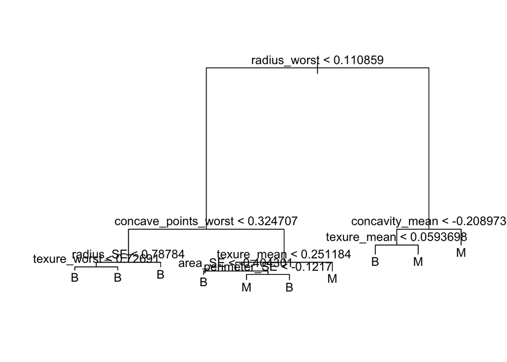

```r
#make tree using scaled data
cancer.scaled.train <- cancer.scaled[1:500,]
cancer.scaled.test <- cancer.scaled[501:569,]
cancer.scaled.train.target<- cancer_data[1:500,2]
cancer.scaled.test.target <- cancer_data[501:569,2]
cancer.tree.scaled <- tree(cancer_data[1:500,2]~., data=cancer.scaled.train)
plot(cancer.tree.scaled)
text(cancer.tree.scaled)
```

```r
#make tree using normalized data
cancer.normalized.train <- cancer.normalized[1:500,]
cancer.normalized.test <- cancer.normalized[501:569,]
cancer.normalized.train.target<- cancer_data[1:500,2]
cancer.normalized.test.target <- cancer_data[501:569,2]
cancer.tree.normalized <- tree(cancer_data[1:500,2]~., data=cancer.normalized.train)
plot(cancer.tree.normalized)
text(cancer.tree.normalized)
```

[output not shown]

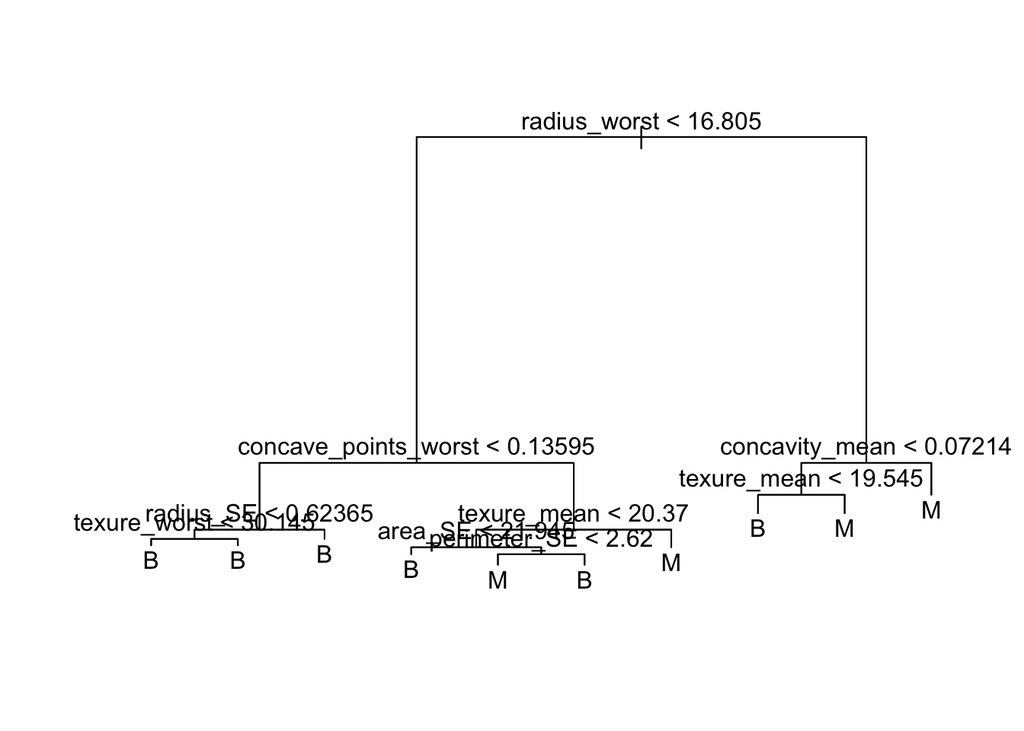

```r
#make tree using unscaled data
cancer.unscaled.train <- cancer.unscaled[1:500,]
cancer.unscaled.test <- cancer.unscaled[501:569,]
cancer.unscaled.train.target<- cancer_data[1:500,2]
cancer.unscaled.test.target <- cancer_data[501:569,2]
cancer.tree.unscaled <- tree(cancer_data[1:500,2]~., data=cancer.unscaled.train)
plot(cancer.tree.unscaled)
text(cancer.tree.unscaled)
```

```r
#evaluate the performence of these three models

#model using scaled data
scaled.pred <- predict(cancer.tree.scaled, cancer.scaled.test, type= "class")
CrossTable(cancer.scaled.test.target, scaled.pred, prop.chisq = F, prop.c = F, prop.r = F, dnn = c('actual type', 'predicted type'))
```

```
##
##
##    Cell Contents
## |-------------------------|
## |                       N |
## |         N / Table Total |
## |-------------------------|
##
##
## Total Observations in Table:  69
##
##
##              | predicted type
##  actual type |         B |         M | Row Total |
## -------------|-----------|-----------|-----------|
##            B |        38 |         1 |        39 |
##              |     0.551 |     0.014 |           |
## -------------|-----------|-----------|-----------|
##            M |         4 |        26 |        30 |
##              |     0.058 |     0.377 |           |
## -------------|-----------|-----------|-----------|
## Column Total |        42 |        27 |        69 |
## -------------|-----------|-----------|-----------|
##
##
```

```r
#model using normalized data
normalized.pred <- predict(cancer.tree.normalized, cancer.normalized.test, type="class")
CrossTable(cancer.normalized.test.target, normalized.pred, prop.chisq = F, prop.c = F, prop.r = F, dnn = c('actual type', 'predicted type'))
```

```
##
##
##    Cell Contents
## |-------------------------|
## |                       N |
## |         N / Table Total |
## |-------------------------|
##
##
## Total Observations in Table:  69
##
##
##              | predicted type
##  actual type |         B |         M | Row Total |
## -------------|-----------|-----------|-----------|
##            B |        38 |         1 |        39 |
##              |     0.551 |     0.014 |           |
## -------------|-----------|-----------|-----------|
##            M |         4 |        26 |        30 |
##              |     0.058 |     0.377 |           |
## -------------|-----------|-----------|-----------|
## Column Total |        42 |        27 |        69 |
## -------------|-----------|-----------|-----------|
##
##
```

```r
#model using unscaled data
unscaled.pred <- predict(cancer.tree.unscaled, cancer.unscaled.test, type="class")
CrossTable(cancer.unscaled.test.target, unscaled.pred, prop.chisq = F, prop.c = F, prop.r = F, dnn = c('actual type', 'predicted type'))
```

```
##
##
##    Cell Contents
## |-------------------------|
## |                       N |
## |         N / Table Total |
## |-------------------------|
##
##
## Total Observations in Table:  69
##
##
##              | predicted type
##  actual type |         B |         M | Row Total |
## -------------|-----------|-----------|-----------|
##            B |        38 |         1 |        39 |
##              |     0.551 |     0.014 |           |
## -------------|-----------|-----------|-----------|
##            M |         4 |        26 |        30 |
##              |     0.058 |     0.377 |           |
## -------------|-----------|-----------|-----------|
## Column Total |        42 |        27 |        69 |
## -------------|-----------|-----------|-----------|
##
##
```

The misclassification of three models are same. The transformation of data will not effect the outputs of the decision tree. The tree structure remain the same with or without the data transformation. So scaling, normalization or leaving the data unscaled makes no difference.